# Homework 10

Luis Alvarez

2026-02-12

## Instructions

Answer the following questions and complete the exercises in RMarkdown. Please embed all of your code and push your final work to your repository. Your final lab report should be organized, clean, and run free from errors. Remember, you must remove the `#` for the included code chunks to run. Be sure to add your name to the author header above.

Make sure to use the formatting conventions of RMarkdown to make your report neat and clean!

## Background

In the `data` folder, you will find data about shark incidents in California between 1950-2022. The [data](https://catalog.data.gov/dataset/shark-incident-database-california-56167) are from: State of California- Shark Incident Database.

## Load the libraries

```r
library("tidyverse")
library("janitor")
```

## Load the data

Run the following code chunk to import the data. In this chunk, I am removing NA’s.

```r
sharks <-
  read_csv("data/SharkIncidents_1950_2022_220302.csv",
           na=c("NA", "N/A", "Unknown", "NOT COUNTED", "", " ")) %>%
  clean_names()
```

## Questions

1. Are there any “hotspots” for shark incidents in California? Show the top five counties with the most incidents.

```r
sharks %>%
  count(county,sort = T) %>%
  head(5)
```

```
## # A tibble: 5 × 2
##   county            n
##   <chr>         <int>
## 1 San Diego        25
## 2 Humboldt         20
## 3 San Mateo        19
## 4 Santa Barbara    19
## 5 Marin            16
```

2. Make a plot that shows the total number of incidents per county.

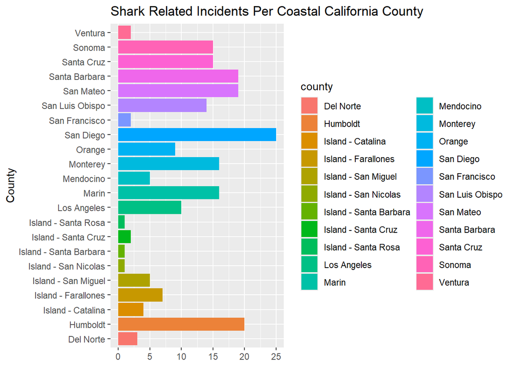

```r
sharks %>%
  ggplot(mapping = aes(x=county, fill = county))+
  geom_bar()+
  coord_flip()+
  labs(title = "Shark Related Incidents Per Coastal California County",
       x="County",
       y=NULL)
```

3. Are there months of the year when incidents are more likely to occur? Make a plot that shows the total number of incidents by month. Which month has the highest number of incidents?

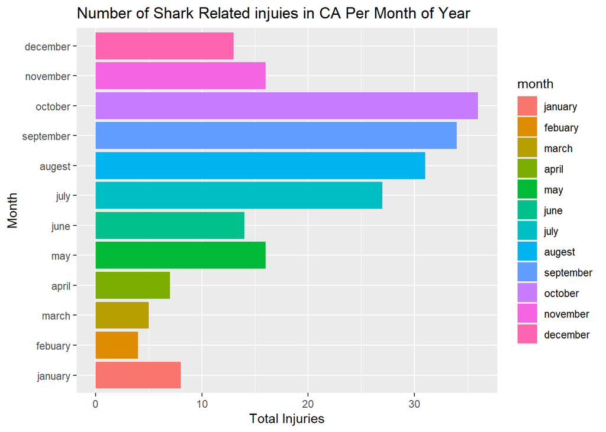

```r
sharks %>%
  select(month) %>%
  mutate(month=as.factor(month)) %>%
  mutate(month=recode(month,
                      "1"="january",
                      "2"="febuary",
                      "3"="march",
                      "4"="april",
                      "5"="may",
                      "6"="june",
                      "7"="july",
                      "8"="augest",
                      "9"="september",
                      "10"="october",
                      "11"="november",
                      "12"="december")) %>%
  ggplot(mapping = aes(x=month,fill= month))+
  geom_bar()+
  coord_flip()+
  labs(title = "Number of Shark Related injuies in CA Per Month of Year",
       x="Month",
       y="Total Injuries")
```

```r
#October has the most incidents a year, there is a trend that the late summer and fall months have the most incidents
```

4. Is there a time of day when most attacks occur? Make a plot that shows the total number of incidents by time of day. Which time of day has the highest number of incidents?

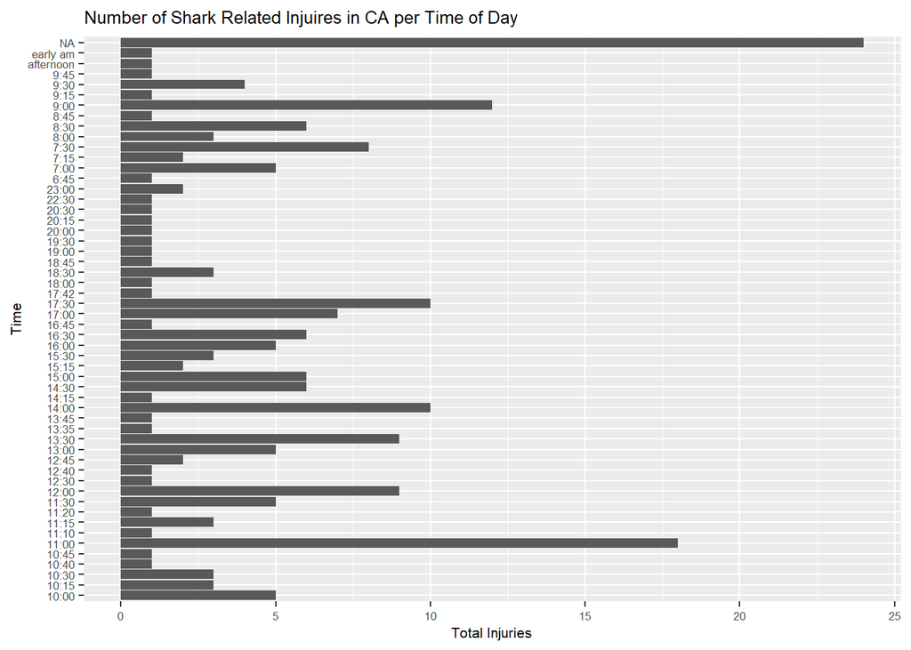

```r
sharks %>%
  select(time) %>%
  ggplot(mapping = aes(x=time))+
  geom_bar()+
  coord_flip()+
  theme(text=element_text(size=8))+
  labs(title = "Number of Shark Related Injuires in CA per Time of Day",
       x="Time",
       y="Total Injuries")
```

```r
#11 Am is when the most attacks occur
```

5. How do the number and types of injuries compare by county? Make a table that shows the number of injury types by county. Which county has the highest number incidents? (hint: your table should be in wide format)

```r
sharks2 <- sharks %>%
  select(county,injury) %>%
  mutate(injury=as.factor(injury)) %>%
  group_by(county, injury) %>%
  summarise(count = n()) %>%
  summarise(total=sum(count))
sharks2
```

```
## # A tibble: 22 × 2
##    county                 total
##    <chr>                  <int>
##  1 Del Norte                  3
##  2 Humboldt                  20
##  3 Island - Catalina          4
##  4 Island - Farallones        7
##  5 Island - San Miguel        5
##  6 Island - San Nicolas       1
##  7 Island - Santa Barbara     1
##  8 Island - Santa Cruz        2
##  9 Island - Santa Rosa        1
## 10 Los Angeles               10
## # ℹ 12 more rows
```

```r
# San Diego has the most injuries
#I dont understand why this table needs to be in wide format when long does the same?
```

6. Use the table from #5 to make a plot that shows the total number of incidents by county.

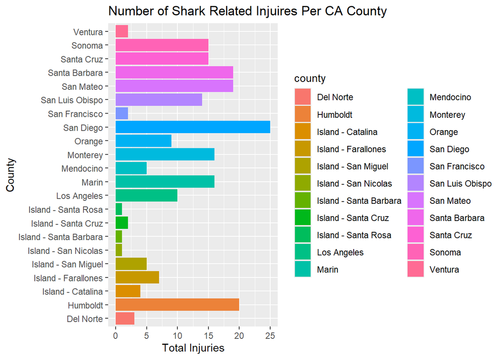

```r
sharks2 %>%
  ggplot(aes(x=county, y=total)) +
  geom_col(aes(fill = county))+
  coord_flip()+
  labs(title = "Number of Shark Related Injuires Per CA County",
       x="County",
       y="Total Injuries")
```

7. In the data, `mode` refers to a type of activity. Which activity is associated with the highest number of incidents?

```r
sharks3 <- sharks %>%
  select(mode,injury) %>%
  mutate(injury=as.factor(injury)) %>%
  group_by(mode, injury) %>%
  summarise(count = n()) %>%
  summarise(total=sum(count))
sharks3
```

```
## # A tibble: 8 × 2
##   mode                total
##   <chr>               <int>
## 1 Freediving             36
## 2 Hookah Diving          10
## 3 Kayaking / Canoeing    30
## 4 Paddleboarding          7
## 5 Scuba Diving           20
## 6 Surfing / Boarding     85
## 7 Swimming               22
## 8 Walking in shallow      1
```

```r
#Surfing has the highest number of shark injuries
```

8. Make a plot that compares the number of incidents by activity.

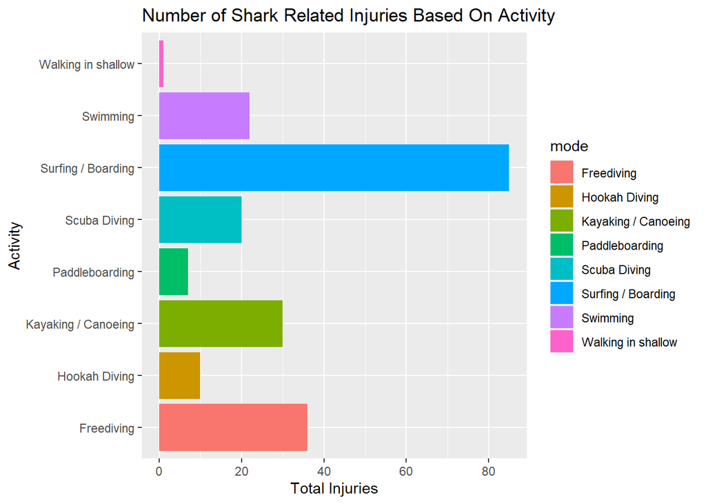

```r
sharks3 %>%
  ggplot(aes(x=mode, y=total)) +
  geom_col(aes(fill = mode))+
  coord_flip()+
  labs(title = "Number of Shark Related Injuries Based On Activity",
       x="Activity",
       y="Total Injuries")
```

9. Which shark species is involved in the highest number of incidents?

```r
sharks4 <- sharks %>%
  select(species,injury) %>%
  mutate(injury=as.factor(injury)) %>%
  group_by(species, injury) %>%
  summarise(count = n()) %>%
  summarise(total=sum(count))
sharks4
```

```
## # A tibble: 12 × 2
##    species      total
##    <chr>        <int>
##  1 Blue             2
##  2 Blue*            1
##  3 Hammerhead       3
##  4 Killer Whale     2
##  5 Leopard          2
##  6 Mako             1
##  7 Salmon           2
##  8 Sevengill        1
##  9 Thresher         1
## 10 White          181
## 11 blue             1
## 12 <NA>            14
```

```r
#Great Whites are responsibe for the highest number of injuries
```

10. Are all incidents involving Great White’s fatal? Make a plot that shows the number and types of incidents for Great White’s only.

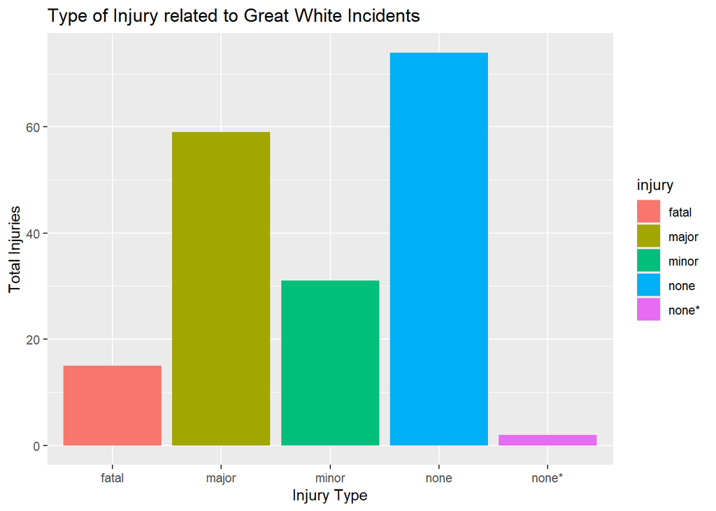

```r
sharks %>%
  select(species,injury) %>%
  filter(species=="White") %>%
  mutate(injury=as.factor(injury)) %>%
  group_by(species, injury) %>%
  summarise(count=n()) %>%
  ggplot(aes(x=injury, y=count))+
  geom_col(aes(fill = injury)) +
  labs(title = "Type of Injury related to Great White Incidents",
       x="Injury Type",
       y="Total Injuries")
```

```r
#Not all Great White incidents are fatal but the ones that do occur leave either no injury or major injury
```

## Knit and Upload

Please knit your work as an .html file and upload to Canvas. Homework is due before the start of the next lab. No late work is accepted. Make sure to use the formatting conventions of RMarkdown to make your report neat and clean!